# 11 Gene Enrichment Analysis III

Removed Ribosomal &Mitochondria-Related Genes from DESeq2 Results

Published

November 5, 2025

To identify biological pathways and processes affected by Cre-mediated ApoE4→ApoE2 conversion in liver tissue, we performed complementary enrichment analyses using the high-confidence differentially expressed genes from Method 1 (combined batches, no batch adjustment).

*Removed 16 mitochondrial genes and 146 ribosomal genes from the dataset*.

### 11.0.1 Gene Set Enrichment Analysis (GSEA)

| pathway | NES | padj | size |
| --- | --- | --- | --- |
| GOBP_MITOCHONDRIAL_RESPIRATORY_CHAIN_COMPLEX_ASSEMBLY | 2.056 | 0.018 | 96 |

Gene Set Enrichment Analysis (GSEA) of the complete ranked gene list, excluding mitochondrial and ribosomal genes, identified enrichment of the mitochondrial respiratory chain complex assembly in the liver upon *ApoE2* switch (NES = 2.056, padj = 0.018).

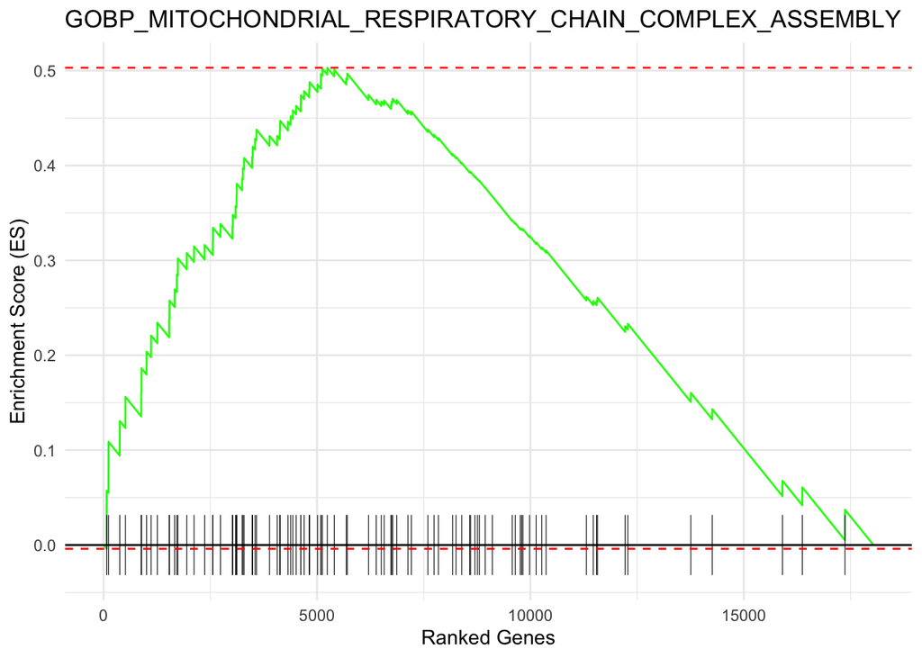

There are 50 leading-edge genes driving the enrichment of the GOBP_MITOCHONDRIAL_RESPIRATORY_CHAIN_COMPLEX_ASSEMBLY, including Ndufb4b, Pet117, Ndufb4c, Ndufb1, Ndufb3, Ndufb8, Ndufaf2, Lyrm2, Ndufs4, Pet100, among others._All these genes are nuclear-encoded mitochondrial proteins involved in electron transport and ATP synthesis_ and are upregulated in liver following ApoE4→ApoE2 conversion.

## 11.1 Brain

### 11.1.1 Gene Set Enrichment Analysis (GSEA)

| pathway | NES | padj | size |
| --- | --- | --- | --- |
| GOBP_EPOXYGENASE_P450_PATHWAY | 2.236 | 0.030 | 26 |
| GOBP_REGULATION_OF_CHROMATIN_ORGANIZATION | 2.218 | 0.013 | 35 |
| GOBP_ARACHIDONIC_ACID_METABOLIC_PROCESS | 2.210 | 0.011 | 59 |
| GOBP_XENOBIOTIC_METABOLIC_PROCESS | 2.139 | 0.006 | 98 |
| GOBP_SPLICEOSOMAL_COMPLEX_ASSEMBLY | 2.121 | 0.029 | 49 |
| GOBP_POSITIVE_REGULATION_OF_MRNA_CATABOLIC_PROCESS | 1.889 | 0.038 | 91 |
| GOBP_CELLULAR_RESPONSE_TO_XENOBIOTIC_STIMULUS | 1.860 | 0.029 | 153 |
| GOBP_POSITIVE_REGULATION_OF_MRNA_METABOLIC_PROCESS | 1.855 | 0.045 | 125 |
| GOBP_DENDRITE_MORPHOGENESIS | 1.854 | 0.011 | 188 |
| GOBP_ACTION_POTENTIAL | 1.815 | 0.013 | 160 |
| GOBP_REGULATION_OF_MRNA_METABOLIC_PROCESS | 1.813 | 0.006 | 274 |
| GOBP_RESPONSE_TO_ALCOHOL | 1.778 | 0.045 | 164 |
| GOBP_DENDRITE_DEVELOPMENT | 1.711 | 0.010 | 315 |
| GOBP_SYNAPSE_ASSEMBLY | 1.609 | 0.045 | 267 |
| GOBP_CHROMATIN_REMODELING | 1.519 | 0.010 | 472 |
| GOBP_MRNA_PROCESSING | 1.460 | 0.044 | 453 |
| GOBP_OXIDATIVE_PHOSPHORYLATION | -2.060 | 0.045 | 124 |

GSEA of brain tissue revealed 17 significantly enriched pathways.

#### 11.1.1.1 Reducing Redundant Pathways with `collapsePathways`

Because many pathways shared the same leading-edge genes, we used the `collapsePathways` function from the `fgsea` package to remove redundancy and isolate distinct biological themes. This method groups pathways with overlapping gene sets and keeps only the most significantly enriched representative from each cluster, ensuring that the analysis reflects independent biological processes rather than repetitive signals.

| pathway | NES | padj | size |
| --- | --- | --- | --- |
| GOBP_REGULATION_OF_CHROMATIN_ORGANIZATION | 2.218 | 0.013 | 35 |
| GOBP_ARACHIDONIC_ACID_METABOLIC_PROCESS | 2.210 | 0.011 | 59 |
| GOBP_SPLICEOSOMAL_COMPLEX_ASSEMBLY | 2.121 | 0.029 | 49 |
| GOBP_CELLULAR_RESPONSE_TO_XENOBIOTIC_STIMULUS | 1.860 | 0.029 | 153 |
| GOBP_ACTION_POTENTIAL | 1.815 | 0.013 | 160 |
| GOBP_REGULATION_OF_MRNA_METABOLIC_PROCESS | 1.813 | 0.006 | 274 |
| GOBP_RESPONSE_TO_ALCOHOL | 1.778 | 0.045 | 164 |
| GOBP_DENDRITE_DEVELOPMENT | 1.711 | 0.010 | 315 |
| GOBP_SYNAPSE_ASSEMBLY | 1.609 | 0.045 | 267 |
| GOBP_CHROMATIN_REMODELING | 1.519 | 0.010 | 472 |
| GOBP_OXIDATIVE_PHOSPHORYLATION | -2.060 | 0.045 | 124 |

This analysis identified 11 representative pathways that summarize the main biological processes affected by hepatic *ApoE2* expression. The refined pathway set highlighted significant changes in chromatin organization, lipid metabolism, synaptic remodeling, and mitochondrial function in brain tissue.

Notably, genes related to oxidative phosphorylation showed reduced expression in the brain, in contrast to their increase in the liver, indicating a distinct metabolic adjustment driven by altered *ApoE* signaling.

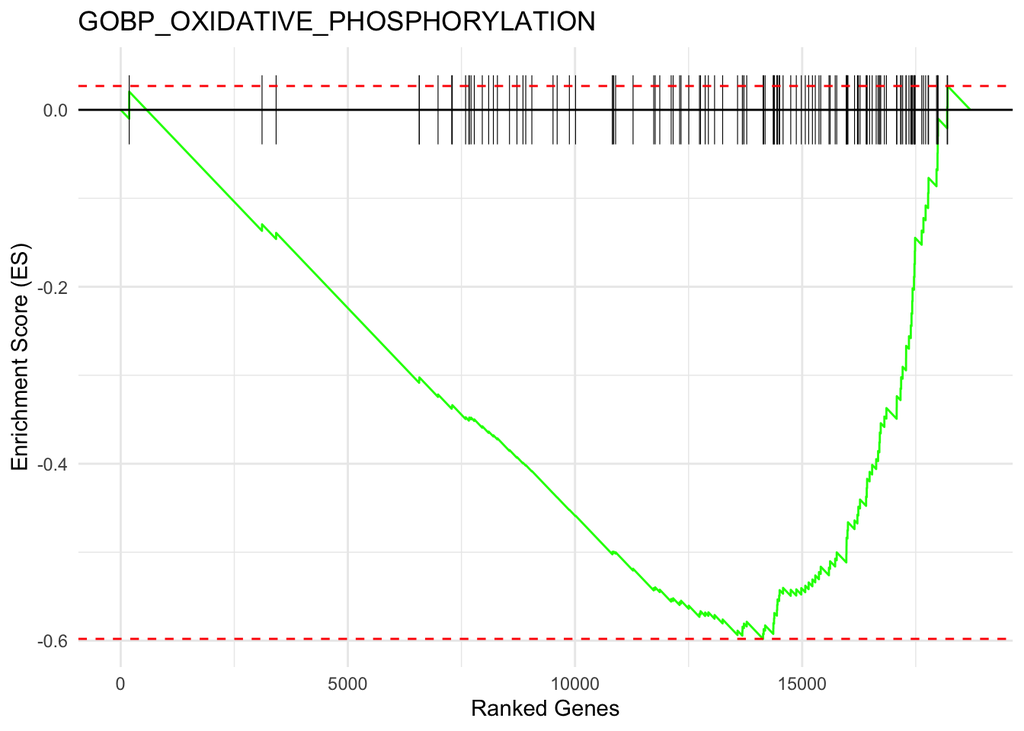

## 11.2 Common Leading-Edge Genes in Liver and Brain

Leading-edge analysis revealed several mitochondrial genes as main contributors to pathway enrichment in both liver and brain. To pinpoint shared molecular mechanisms underlying the effects of ApoE isoform conversion, we compared the overlapping leading-edge genes between the two tissues.

This analysis identified 12 mitochondrial genes commonly altered in both liver and brain following ApoE4→ApoE2 conversion: Uqcc2, Ndufb4, Ndufb9, Ndufb2, Ndufs5, Ndufs8, Ndufb6, Ndufs6, Ndufb8, Ndufb7, Sdhaf2, Ndufb5

| tissue | gene | log2FoldChange | padj |
| --- | --- | --- | --- |
| brain | Ndufb2 | -0.433 | 0.000 |
| liver | Ndufb2 | 0.294 | 0.055 |
| brain | Ndufb4 | -0.503 | 0.000 |
| liver | Ndufb4 | 0.561 | 0.001 |
| brain | Ndufb5 | -0.211 | 0.000 |
| liver | Ndufb5 | 0.259 | 0.002 |
| brain | Ndufb6 | -0.344 | 0.000 |
| liver | Ndufb6 | 0.384 | 0.000 |
| brain | Ndufb7 | -0.256 | 0.000 |
| liver | Ndufb7 | 0.341 | 0.004 |
| brain | Ndufb8 | -0.270 | 0.000 |
| liver | Ndufb8 | 0.765 | 0.000 |
| brain | Ndufb9 | -0.465 | 0.000 |
| liver | Ndufb9 | 0.379 | 0.016 |
| brain | Ndufs5 | -0.417 | 0.000 |
| liver | Ndufs5 | 0.267 | 0.055 |
| brain | Ndufs6 | -0.341 | 0.000 |
| liver | Ndufs6 | 0.346 | 0.005 |
| brain | Ndufs8 | -0.384 | 0.000 |
| liver | Ndufs8 | 0.280 | 0.004 |
| brain | Sdhaf2 | -0.212 | 0.000 |
| liver | Sdhaf2 | 0.254 | 0.015 |
| brain | Uqcc2 | -0.545 | 0.000 |
| liver | Uqcc2 | 0.386 | 0.030 |

These genes showed opposite patterns of regulation, increasing in the liver while decreasing in the brain. This contrast indicates that hepatic *ApoE2* expression influences mitochondrial function in a tissue-specific manner, likely shaping the broader metabolic adjustments observed in this model.

## 11.3 Analysis of Brain metabolic Genes

To understand how hepatic *ApoE2* expression influences **brain** energy metabolism, we analyzed genes involved in glucose transport, glycolysis, lactate shuttling, glycogen turnover, and mitochondrial function. Most genes in these pathways showed modest but consistent shifts, revealing a coordinated metabolic adjustment rather than isolated changes.

`log2FoldChange` indicates differential expression in brain following hepatic ApoE4→ApoE2 conversion (i.e., ApoE2 effect).

### 11.3.1 Glycolysis Core Genes

Several glycolytic enzymes, including *Aldoa*, *Pgk1*, *Eno1*, *Ldha*, and *Aldoc*, showed reduced expression, suggesting a slower glycolytic flux. In contrast, *Hk1* increased, indicating stronger glucose trapping within cells. Together, these changes suggest a transition from rapid anaerobic glycolysis toward more regulated and efficient glucose utilization.

| gene | log2FoldChange | padj |
| --- | --- | --- |
| Ldhb | -0.272 | 0.000 |
| Aldoa | -0.354 | 0.000 |
| Pgk1 | -0.209 | 0.000 |
| Eno1 | -0.261 | 0.000 |
| Aldoc | -0.237 | 0.002 |
| Ldha | -0.299 | 0.009 |
| Pgam1 | -0.124 | 0.010 |
| Hk1 | 0.213 | 0.016 |
| Eno3 | -0.479 | 0.017 |
| Gapdh | -0.122 | 0.021 |
| Pkm | -0.108 | 0.082 |
| Gck | -0.427 | 0.110 |
| Pfkp | 0.114 | 0.172 |
| Pklr | -0.733 | 0.385 |
| Hk3 | -0.281 | 0.421 |
| Pfkl | -0.103 | 0.456 |
| Pgam2 | 0.120 | 0.607 |
| Aldob | 0.237 | 0.673 |
| Hk2 | 0.028 | 0.890 |
| Eno2 | 0.008 | 0.912 |
| Pfkm | -0.002 | 0.980 |

### 11.3.2 Glucose Transporter Genes

Among glucose transporter genes, *Slc2a1*, *Slc2a6*, and *Slc2a8* showed reduced expression in brain tissue following hepatic *ApoE4→ApoE2* conversion, while *Slc2a3* displayed a mild increase. Other transporters, including *Slc2a4*, *Slc5a1*, and *Slc2a2*, did not show significant changes.

| gene | log2FoldChange | padj |
| --- | --- | --- |
| Slc2a6 | -0.465 | 0.000 |
| Slc2a1 | -0.288 | 0.002 |
| Slc2a8 | -0.298 | 0.004 |
| Slc2a3 | 0.174 | 0.080 |
| Slc2a4 | -0.182 | 0.355 |
| Slc5a1 | -0.241 | 0.431 |
| Slc2a2 | 0.296 | NA |

### 11.3.3 Pentose Phosphate Pathway Genes

Within the pentose phosphate pathway, *Tkt* showed decreased expression in brain tissue following hepatic *ApoE4→ApoE2* conversion. The remaining genes analyzed, *Rpia*, *Pgd*, and *Rpe*, did not display significant expression changes.

| gene | log2FoldChange | padj |
| --- | --- | --- |
| Tkt | -0.225 | 0.000 |
| Rpia | 0.136 | 0.214 |
| Pgd | -0.013 | 0.879 |
| Rpe | 0.001 | 0.996 |

### 11.3.4 Pyruvate metabolism Genes

Lower *Pdk2* and higher *Pdp1* and *Pdp2* expression reopen the pyruvate dehydrogenase complex, enabling glucose-derived pyruvate to enter the TCA cycle and support oxidative metabolism.

| gene | log2FoldChange | padj |
| --- | --- | --- |
| Pdp1 | 0.207 | 0.001 |
| Pdk2 | -0.193 | 0.001 |
| Pdk3 | 0.184 | 0.001 |
| Pck2 | -0.318 | 0.002 |
| Dld | 0.115 | 0.007 |
| Dlat | 0.176 | 0.022 |
| Pdp2 | 0.233 | 0.022 |
| Pdhx | 0.096 | 0.040 |
| Pdha1 | 0.114 | 0.094 |
| Pdk1 | 0.114 | 0.237 |
| Pdk4 | 0.107 | 0.369 |
| Pdhb | 0.038 | 0.393 |
| Pck1 | 1.001 | NA |

### 11.3.5 Lactate Transporter Genes

Lactate transporter genes reflected a rebalancing of the astrocyte–neuron metabolic coupling. The reduction of *Slc16a3* (MCT4) and the increase of *Slc16a7* (MCT2) suggest less lactate export from astrocytes and greater neuronal uptake, restoring a healthy lactate shuttle.

| gene | log2FoldChange | padj |
| --- | --- | --- |
| Slc16a7 | 0.436 | 0.002 |
| Slc16a14 | 0.454 | 0.004 |
| Slc16a3 | -0.431 | 0.015 |
| Slc16a8 | -0.606 | 0.023 |
| Slc16a11 | -0.429 | 0.049 |
| Slc16a10 | 0.234 | 0.101 |
| Slc16a1 | -0.012 | 0.936 |
| Slc16a13 | 0.015 | 0.938 |

### 11.3.6 Glycogen Metabolism Genes

Regulators of glycogen metabolism, such as *Pygm*, *Agl*, and *Phka2*, also adjusted in line with this more stable metabolic state, showing decreased mobilization of glycogen stores.

| gene | log2FoldChange | padj |
| --- | --- | --- |
| Pygm | -0.235 | 0.010 |
| Agl | 0.164 | 0.035 |
| Phka2 | 0.209 | 0.039 |
| Gbe1 | 0.125 | 0.151 |
| Phkg1 | -0.109 | 0.383 |
| Pygl | -0.107 | 0.423 |
| Pygb | -0.034 | 0.650 |
| Gys1 | -0.043 | 0.653 |
| Phka1 | -0.022 | 0.828 |
| Aga | -0.008 | 0.956 |
| Gys2 | -0.149 | NA |

### 11.3.7 Metabolic Regulators

Several metabolic regulators changed expression in brain tissue following hepatic *ApoE4→ApoE2* conversion. *Insr*, *Gsk3b*, *Prkaa2*, *Pik3ca*, *Akt3*, *Irs1*, *Pik3cb*, and *Prkaa1* were upregulated, while *Akt1*, *Prkag1*, *Akt2*, and *Rheb* were downregulated. *Plin2* also decreased in expression. Other genes, including *Mtor*, *Irs2*, *Prkab1*, *Stk11*, *Prkag2*, *Prkab2*, and *Gsk3a*, showed minor or nonsignificant changes.

| gene | log2FoldChange | padj |
| --- | --- | --- |
| Insr | 0.358 | 0.000 |
| Gsk3b | 0.453 | 0.000 |
| Akt1 | -0.215 | 0.000 |
| Prkag1 | -0.253 | 0.000 |
| Akt2 | -0.237 | 0.000 |
| Prkaa2 | 0.348 | 0.001 |
| Pik3ca | 0.262 | 0.001 |
| Akt3 | 0.289 | 0.002 |
| Irs1 | 0.286 | 0.004 |
| Pik3cb | 0.216 | 0.007 |
| Prkaa1 | 0.196 | 0.019 |
| Plin2 | -0.231 | 0.023 |
| Depdc5 | 0.139 | 0.031 |
| Rheb | -0.160 | 0.034 |
| Mtor | 0.148 | 0.061 |
| Irs2 | 0.153 | 0.074 |
| Prkab1 | -0.154 | 0.093 |
| Stk11 | -0.050 | 0.352 |
| Prkag2 | 0.068 | 0.500 |
| Prkab2 | 0.053 | 0.689 |
| Gsk3a | -0.024 | 0.690 |

### 11.3.9 Mitochondrial Transport Genes

Mitochondrial transporter genes (*Mpc1*, *Mpc2*, *Slc25a1*, *Slc25a10*) declined, indicating lower demand for emergency substrate import.

| gene | log2FoldChange | padj |
| --- | --- | --- |
| Slc25a10 | -0.495 | 0.000 |
| Slc25a1 | -0.435 | 0.000 |
| Slc25a11 | -0.383 | 0.000 |
| Mpc2 | -0.276 | 0.000 |
| Mpc1 | -0.206 | 0.001 |

### 11.3.10 All metabolic pathways (only significant genes )

This section lists all genes with **significant expression changes** across major metabolic pathways in brain tissue after hepatic ApoE4→ApoE2 conversion.

| id | gene | log2FoldChange | padj |
| --- | --- | --- | --- |
| glucose_transporters | Slc2a6 | -0.465 | 0.000 |
| glucose_transporters | Slc2a1 | -0.288 | 0.002 |
| glucose_transporters | Slc2a8 | -0.298 | 0.004 |
| glyco_core | Ldhb | -0.272 | 0.000 |
| glyco_core | Aldoa | -0.354 | 0.000 |
| glyco_core | Pgk1 | -0.209 | 0.000 |
| glyco_core | Eno1 | -0.261 | 0.000 |
| glyco_core | Aldoc | -0.237 | 0.002 |
| glyco_core | Ldha | -0.299 | 0.009 |
| glyco_core | Pgam1 | -0.124 | 0.010 |
| glyco_core | Hk1 | 0.213 | 0.016 |
| glyco_core | Eno3 | -0.479 | 0.017 |
| glyco_core | Gapdh | -0.122 | 0.021 |
| glycogen_metabolism | Pygm | -0.235 | 0.010 |
| glycogen_metabolism | Agl | 0.164 | 0.035 |
| glycogen_metabolism | Phka2 | 0.209 | 0.039 |
| lactate_transport | Slc16a7 | 0.436 | 0.002 |
| lactate_transport | Slc16a14 | 0.454 | 0.004 |
| lactate_transport | Slc16a3 | -0.431 | 0.015 |
| lactate_transport | Slc16a8 | -0.606 | 0.023 |
| lactate_transport | Slc16a11 | -0.429 | 0.049 |
| metabolic_regulators | Insr | 0.358 | 0.000 |
| metabolic_regulators | Gsk3b | 0.453 | 0.000 |
| metabolic_regulators | Akt1 | -0.215 | 0.000 |
| metabolic_regulators | Prkag1 | -0.253 | 0.000 |
| metabolic_regulators | Akt2 | -0.237 | 0.000 |
| metabolic_regulators | Prkaa2 | 0.348 | 0.001 |
| metabolic_regulators | Pik3ca | 0.262 | 0.001 |
| metabolic_regulators | Akt3 | 0.289 | 0.002 |
| metabolic_regulators | Irs1 | 0.286 | 0.004 |
| metabolic_regulators | Pik3cb | 0.216 | 0.007 |
| metabolic_regulators | Prkaa1 | 0.196 | 0.019 |
| metabolic_regulators | Plin2 | -0.231 | 0.023 |
| metabolic_regulators | Depdc5 | 0.139 | 0.031 |
| metabolic_regulators | Rheb | -0.160 | 0.034 |
| mitochondrial_transport | Slc25a10 | -0.495 | 0.000 |
| mitochondrial_transport | Slc25a1 | -0.435 | 0.000 |
| mitochondrial_transport | Slc25a11 | -0.383 | 0.000 |
| mitochondrial_transport | Mpc2 | -0.276 | 0.000 |
| mitochondrial_transport | Mpc1 | -0.206 | 0.001 |
| pentose_phosphate_pathway | Tkt | -0.225 | 0.000 |
| pyruvate_metabolism | Pdp1 | 0.207 | 0.001 |
| pyruvate_metabolism | Pdk2 | -0.193 | 0.001 |
| pyruvate_metabolism | Pdk3 | 0.184 | 0.001 |
| pyruvate_metabolism | Pck2 | -0.318 | 0.002 |
| pyruvate_metabolism | Dld | 0.115 | 0.007 |
| pyruvate_metabolism | Dlat | 0.176 | 0.022 |
| pyruvate_metabolism | Pdp2 | 0.233 | 0.022 |
| pyruvate_metabolism | Pdhx | 0.096 | 0.040 |

The data show that the *ApoE4* mouse brain lives under chronic metabolic stress, a condition reversed by hepatic *ApoE2* expression. The *ApoE4* state is marked by glucose hypometabolism, which forces astrocytes to accumulate small lipid droplets stabilized by high *Plin2* expression. This is not a resting phase but an inefficient, oxygen-hungry state where fatty acids are oxidized incompletely, producing metabolic intermediates (Farmer, Kluemper, and Johnson 2019). An accompanying rise in *Slc2a1*, *Slc2a6*, *Slc2a8*, *Mpc1*, *Mpc2*, *Slc25a1*, and *Slc25a10* may reflect a failed attempt to compensate for the energy shortage. Hepatic *ApoE2* expression restores balance, normalizing these transport systems.

This correction involves a deeper reprogramming of glucose metabolism. In *ApoE4* brains, glycolysis runs fast but inefficiently, shunting pyruvate to lactate through *Ldha* and the astrocytic exporter *Slc16a3* (MCT4). With hepatic *ApoE2*, *Hk1* rises, trapping glucose in cells, while glycolytic enzymes such as *Aldoa*, *Pgk1*, and *Eno1* fall. At the same time, *Pdk2* declines and *Pdp1* and *Pdp2* increase, reopening the pyruvate dehydrogenase complex and steering metabolism toward aerobic respiration. This shift calms glycolytic activity and reduces glycogen breakdown, shown by lower *Pygm* expression.

The lactate shuttle also resets. Astrocytic lactate export drops with reduced *Ldha* and *Slc16a3*, while neuronal uptake improves through *Slc16a7* (MCT2). The fall in *Tkt* suggests that oxidative stress decreases as the pentose phosphate pathway relaxes.

Finally, key regulators of energy balance respond. *Insr* and *Irs1* rise, restoring insulin sensitivity, while *Plin2* declines, signaling relief from lipid stress. The downregulation of oxidative phosphorylation genes confirms that the brain’s metabolism has cooled from a high-output, inefficient state to a steady, aerobic equilibrium. In sum, hepatic *ApoE2* expression resolves the metabolic strain of *ApoE4*, returning the brain to an efficient and balanced homeostasis.

Farmer, Brandon, Jude Kluemper, and Lance Johnson. 2019. “Apolipoprotein E4 Alters Astrocyte Fatty Acid Metabolism and Lipid Droplet Formation.” *Cells* 8 (2): 182. https://doi.org/10.3390/cells8020182.